# Fisseha Berhane, PhD

#### Data Scientist

443-970-2353 fisseha@jhu.edu CV Resume

## Visualizing election predictions using ggplot2

Here, ggplot2 is used to visualize US presidential election predictions using logistic regression on polling data.

First, the data is separated into a training set, containing data from 2004 and 2008 polls, and a test set, containing the data from 2012 polls.Then a logistic regression model is developed to forecast the 2012 US presidential election.

```r
options(jupyter.plot_mimetypes = 'image/png')

options(repr.plot.width = 10)
options(repr.plot.height = 6)
```

```r
library(ggplot2)
library(maps)
library(ggmap)
require(downloader)

statesMap = map_data("state")
```

We can now plot the states using ggplot2

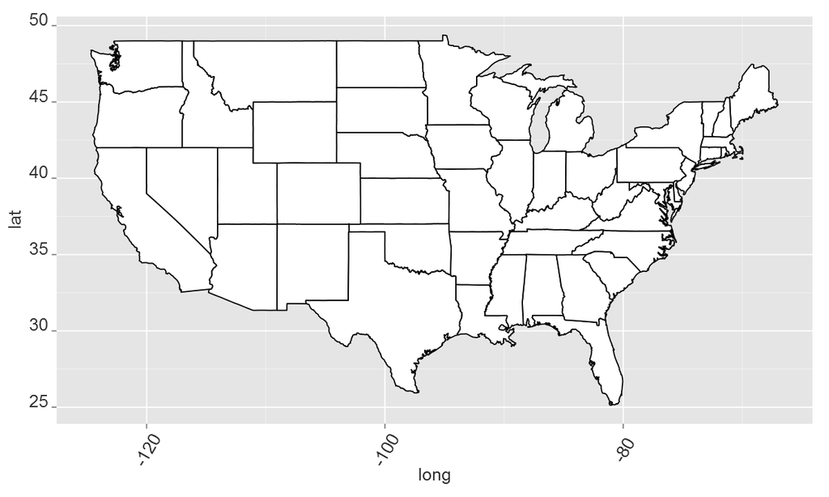

```r
ggplot(statesMap, aes(x = long, y = lat, group = group)) +
geom_polygon(fill = 'white', color = "black") +
theme(axis.title.y = element_text(colour="grey20",size=15,angle=90,hjust=.5,vjust=1,face="plain"),
      axis.title.x = element_text(colour="grey20",size=15,angle=0,hjust=.5,vjust=1,face="plain"),
      axis.text.y = element_text(colour="grey20",size=15,angle=0,hjust=1,vjust=0,face="plain"),
      axis.text.x = element_text(colour="grey20",size=15,angle=60,hjust=.5,vjust=.5,face="plain"))
```

Now, let’s develop a logistic regression model and map the prediction results.

```r
url<-"https://courses.edx.org/asset-v1:MITx+15.071x_2a+2T2015+type@asset+block/PollingImputed.csv"

download(url, dest="PollingImputed.csv")

polling = read.csv("PollingImputed.csv")

# Subset data into training set and test set
Train = subset(polling, Year == 2004 | Year == 2008)
Test = subset(polling, Year == 2012)

mod2 = glm(Republican~SurveyUSA+DiffCount, data=Train, family="binomial")


TestPrediction = predict(mod2, newdata=Test, type="response")
```

TestPrediction gives the predicted probabilities for each state, but let’s also create a vector of Republican/Democrat predictions

```r
TestPredictionBinary = as.numeric(TestPrediction > 0.5)
```

To use ggplot2, predictions and state labels have to be in a data frame.

```r
predictionDataFrame = data.frame(TestPrediction, TestPredictionBinary, Test$State)
```

Now, we need to merge “predictionDataFrame” with the map data “statesMap”. Before doing so, we need to convert the Test.State variable to lowercase, so that it matches the region variable in statesMap.

```r
predictionDataFrame$region = tolower(predictionDataFrame$Test.State)
predictionMap = merge(statesMap, predictionDataFrame, by = "region")
```

we need to make sure the observations are in order so that the map is drawn properly.

```r
predictionMap = predictionMap[order(predictionMap$order),]
```

Now, we can plot the predictions.

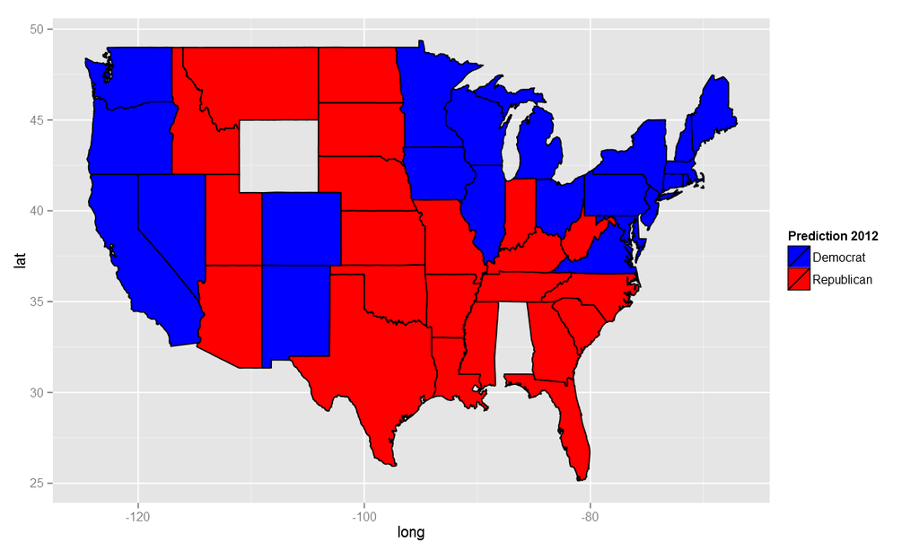

```r
ggplot(predictionMap, aes(x = long, y = lat, group = group, fill = TestPredictionBinary))+
geom_polygon(color = "black") + scale_fill_gradient(low = "blue", high = "red", guide = "legend", breaks= c(0,1), labels = c("Democrat", "Republican"), name = "Prediction 2012")
```

We can play with the color, bourder thickness, line type and transparency.

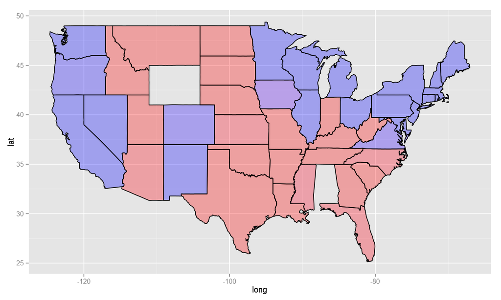

```r
ggplot(predictionMap, aes(x = long, y = lat, group = group, fill = TestPrediction))+
geom_polygon(color = "black", alpha=0.3) +
scale_fill_gradient(low = "blue", high = "red", guide = "legend", breaks= c(0,1))
```

We can also plot the probabilities instead of the binary predictions. Using the deafult color:

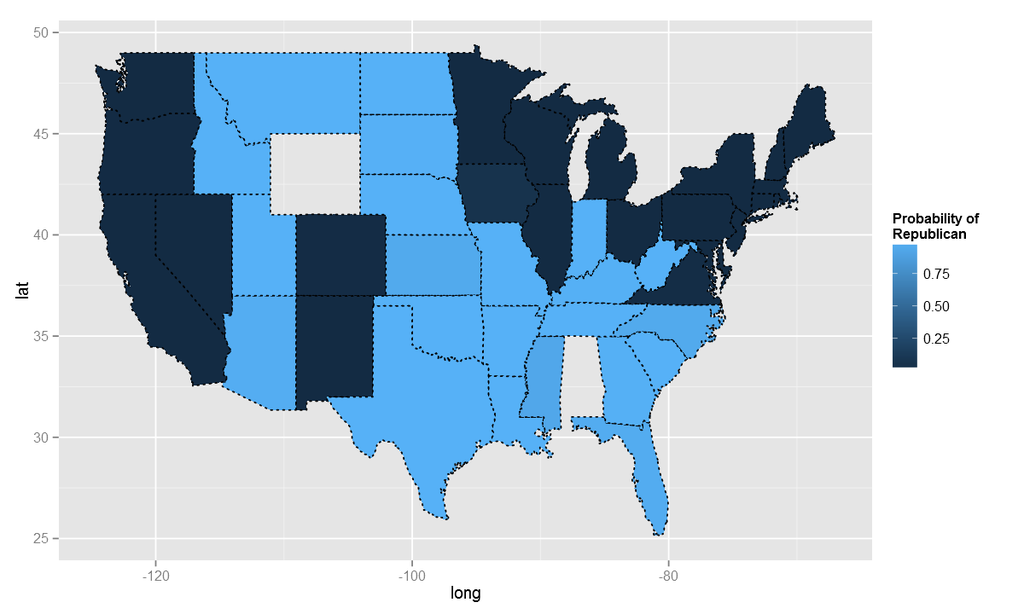

```r
ggplot(predictionMap, aes(x = long, y = lat,
    group = group, fill = TestPrediction,name='Fish'))+
    geom_polygon(color = "black",lty=3)+
    scale_fill_continuous(name="Probability of\nRepublican")
```

[comments powered by Disqus](http://disqus.com)